# PIGAL - Analyse PLS multiblocs suivie d’une classification k-means des variables respiratoires

true

2025-03-19

**Packages**

**Charger les données**

## _______________________________________________________________________________

#Analyse multiblocs - 21 variables X et une variable Y

## _______________________________________________________________________________

data.clean = fichier contenant 21 variables X et une variable Y.

*Etape 1*

On réalise et CODE_ELEVAGEle découpage par les blocs en accord avec le fichier variables_Sujet_22_envoi.xlsx

```r
X01_Logement_Entretien <- data.clean[, c("X22x1_LOC_INF_rec", "X07x1_AN_CONST4_mean_3", "ENG_TROU", "T13_ENG_milieuDegrad.x")]
X02_Alimentation <- data.clean[, c("T10_PS_EauDebi_3", "T10_PS_AlimPoNourrLongpPo", "X09x3_FAB_CROISS_reg_rec")]
X03_Gestion_Maladies <- data.clean[, c("X18x2_ABBTX_PS", "X19x2_ABB_E")]
X04_Biosecurite <- data.clean[, c("X12x2_MAT_PC", "X12x2_MAT1FRLAV_1", "T16_BS_TenueSpeciElev", "X13x2_QUAI_t")]
X05_Facteurs_Infectieux <- data.clean[, c("A03_Pos10sVERS", "A03_PosSeroMyAs", "A03_TxPosSero22sTgReel", "A04_My10Mfloc", "A05_TxPos10sGRIPPEReel")]
X06_Caracteristiques_Generales <- data.clean[, c("X06x1_gene_majo_1_rec", "X25x1_ElvAlterChoiPers", "LR_LRF")]
```

*Etape 2*

Création des dummy (ie binaires) variables avec le package fastDummies. La variable prise en référence correspond à celle dont l’effectif de réponse est le plus élevé.

```r
data <- list(X01_Logement_Entretien, X02_Alimentation, X03_Gestion_Maladies, X04_Biosecurite, X05_Facteurs_Infectieux, X06_Caracteristiques_Generales)

for(i in 1:length(data)){
  df <- data[[i]]
  for(var in names(df)){
    if(is.factor(df[[var]])){
      df <- dummy_cols(df, var, remove_selected_columns = TRUE, remove_most_frequent_dummy = TRUE)
    }
  }
  data[[i]] <- df
}
```

*Etape 3* La variable Y est en 3 modalités donc elle est également recodée en dummy variables selon le code indiqué ci-dessous. Introduction de la variable Y codée en 3 dummy (ie transformation de Y en 3 variables binaires) variables :

```r
dummy_y <- data.frame(y = data.clean$y)

# Create des 3 Y
dummy_y$sain <- as.integer(dummy_y$y == "Sain")
dummy_y$ps_malade <- as.integer(dummy_y$y == "PS_malade")
dummy_y$eng_malade <- as.integer(dummy_y$y == "ENG_malade")

#suppression de y, la variable Y initiale, qui a été récodée en 3 niveaux Y
```

*Etape 4*

Création d’un bloc pour la variable Y codée en dummy variables.

```r
bloc.Y <- dummy_y[,2:4]
data[[7]] <- bloc.Y
```

*Etape 5*

Renommer les blocs:

```r
new_names <- c("X01_Logement_Entretien", "X02_Alimentation", "X03_Gestion_Maladies", "X04_Biosecurite", "X05_Facteurs_Infectieux", "X06_Caracteristiques_Generales", "Bloc_Y")
names(data) <- new_names
```

*Etape 6*

**PASSAGE à l’analyse mbPLS**

## Préparation des données

```r
Y <- data[[7]]

row.names(Y)<-rownames(data[[1]])
#renommer les lignes du nouveau Y par les numéros des data 1 à 7 car Y prend le code elevage (PIGAL/ELEV/01...) alors que les autres fichiers ont un numéro d'ordre (perte du code_elevage); sans cela le code d'après bloque #à voir si cette étape est nécessaire dans votre code selon la configuration de votre fichier.
dudiY.ergo <- dudi.pca(Y, center = TRUE, scale = TRUE, scannf = FALSE)
ktabX.ergo <- ktab.list.df(data[1:6])
```

## mbPLS

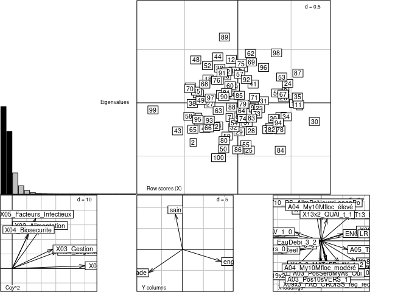

```r
res.mbpls2   <- mbpls(dudiY.ergo, ktabX.ergo, scale = T, option = "uniform", scannf = FALSE, nf = 10)
res.plot     <- plot(res.mbpls2)
```

```r
res.2foldcv2 <- testdim(res.mbpls2, nrepet = 500)  # calcul long
```

## Choix du nombre de dimensions

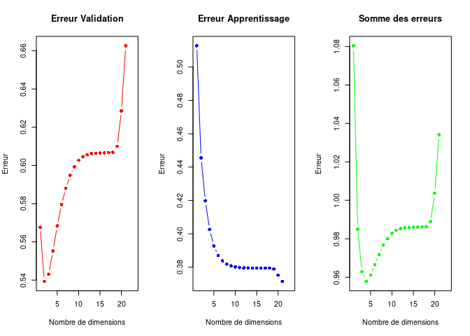

```r
rmsec_values <- res.2foldcv2$statsRMSEc$Mean
rmsec_values[is.nan(rmsec_values)] <- NA
somme <- res.2foldcv2$statsRMSEv$Mean + res.2foldcv2$statsRMSEc$Mean
# Définir les limites de l'axe Y pour inclure les deux courbes
#ylim_range <- range(c(res.2foldcv2$statsRMSEv$Mean, rmsec_values, somme), na.rm = TRUE)
par(mfrow = c(1, 3))
# Tracer la courbe d'erreur de validation (rouge)
plot(1:length(res.2foldcv2$statsRMSEv$Mean), res.2foldcv2$statsRMSEv$Mean, type = "b", pch = 16, col = "red",
     xlab = "Nombre de dimensions", ylab = "Erreur",
     main = "Erreur Validation")

# Ajouter la courbe d'erreur d'apprentissage (bleue)
plot(1:length(rmsec_values), rmsec_values, type = "b", pch = 16, col = "blue",
     xlab = "Nombre de dimensions", ylab = "Erreur",
     main = "Erreur Apprentissage")

plot(1:length(somme), somme, type = "b", pch = 16, col = "green",
     xlab = "Nombre de dimensions", ylab = "Erreur",
     main = "Somme des erreurs")
```

```r
# Sélection dimensions
match(min(na.omit(somme)), somme)
```

```
## [1] 4
```

NB : les variables X sont centrées et réduites à ce niveau On décide alors de garder 4 dimensions.

# Récupération des composantes de tous les axes pour réaliser une classification k-means à partir de ces composantes

```r
#pour les X
recup_compos_X<-res.mbpls2$lX
#pour les Y
recup_compos_Y<-res.mbpls2$lY
```

## Complément sur la variance expliquée des axes : variance expliquée par bloc

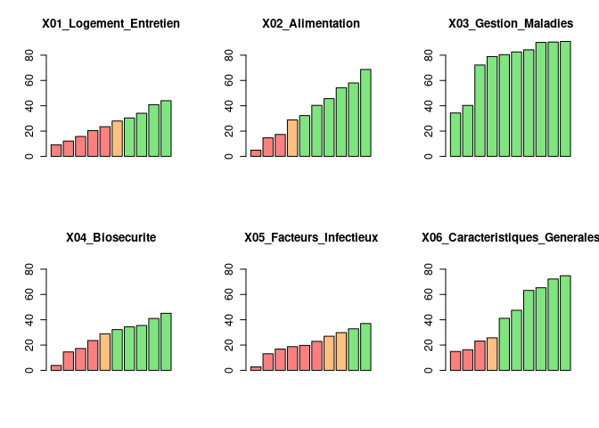

```r
par(mfrow = c(2, 3))
for(name in names(sum_res)[-1]){
    var.cum <- sum_res[[name]][,2]
    color <- ifelse(var.cum <= 25, red, ifelse(var.cum < 30, orange, green))
    barplot(var.cum,
            main=name,
            col = color,
            cex.main=1.25,
            cex.axis=1.2,
            ylim= c(0,87))
}
```

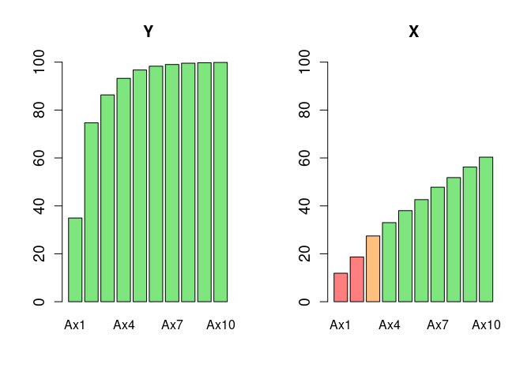

```r
var.cum <- sum_res$YandX[,2]
color <- ifelse(var.cum <= 25, red, ifelse(var.cum < 30, orange, green))

par(mfrow = c(1, 2))
barplot(var.cum,
            main="Y",
            col = color,
            cex.main=1.25,
            cex.axis=1.2,
            ylim= c(0,100))
var.cum <- sum_res$YandX[,4]
color <- ifelse(var.cum <= 25, red, ifelse(var.cum < 30, orange, green))

barplot(var.cum,
            main="X",
            col = color,
            cex.main=1.25,
            cex.axis=1.2,
            ylim= c(0,100))
```

## Classification

L’objectif de cette approche est de regarder si de l’hétérogénéité existe au sein des niveaux de Y et que cela s’explique par des pratiques associées qui sont différentes.

### K-means

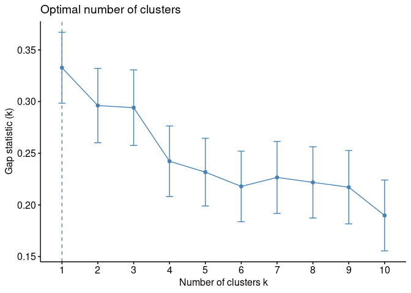

```r
select.4 <- selection_dimensions(recup_compos_X, 2)
select.4
```

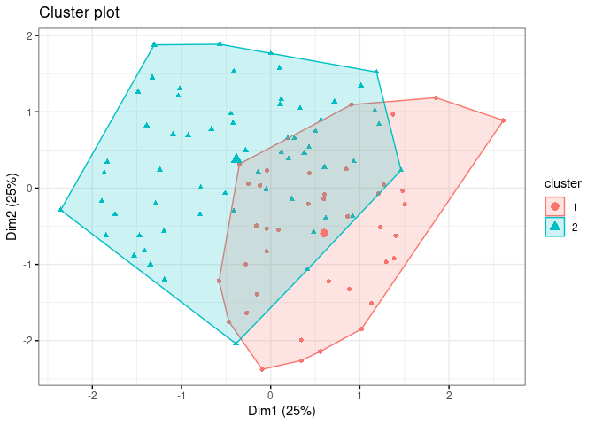

```r
res.4.2 <- analyse_clusters(recup_compos_X, data.clean, 4, 2)
res.4.2$plot.km
```

```r
res.4.2$res.table
```

|  | 1 | 2 | Overall |
| --- | --- | --- | --- |
|  | (N=39) | (N=61) | (N=100) |
| X09x3_FAB_CROISS_reg_rec |  |  |  |
| 0 | 24 (61.5%) | 31 (50.8%) | 55 (55.0%) |
| 1 | 15 (38.5%) | 30 (49.2%) | 45 (45.0%) |
| X22x1_LOC_INF_rec |  |  |  |
| 0 | 25 (64.1%) | 31 (50.8%) | 56 (56.0%) |
| 1 | 14 (35.9%) | 30 (49.2%) | 44 (44.0%) |
| X06x1_gene_majo_1_rec |  |  |  |
| 0 | 11 (28.2%) | 10 (16.4%) | 21 (21.0%) |
| 1 | 28 (71.8%) | 51 (83.6%) | 79 (79.0%) |
| X12x2_MAT_PC |  |  |  |
| 1 | 18 (46.2%) | 18 (29.5%) | 36 (36.0%) |
| 2 | 21 (53.8%) | 43 (70.5%) | 64 (64.0%) |
| T10_PS_EauDebi_3 |  |  |  |
| 0 | 14 (35.9%) | 28 (45.9%) | 42 (42.0%) |
| 1 | 14 (35.9%) | 25 (41.0%) | 39 (39.0%) |
| 2 | 11 (28.2%) | 8 (13.1%) | 19 (19.0%) |
| X12x2_MAT1FRLAV_1 |  |  |  |
| 0 | 10 (25.6%) | 17 (27.9%) | 27 (27.0%) |
| 1 | 15 (38.5%) | 22 (36.1%) | 37 (37.0%) |
| 2 | 14 (35.9%) | 22 (36.1%) | 36 (36.0%) |
| X07x1_AN_CONST4_mean_3 |  |  |  |
| 0 | 13 (33.3%) | 20 (32.8%) | 33 (33.0%) |
| 1 | 8 (20.5%) | 17 (27.9%) | 25 (25.0%) |
| 2 | 18 (46.2%) | 24 (39.3%) | 42 (42.0%) |
| T16_BS_TenueSpeciElev |  |  |  |
| 0 | 7 (17.9%) | 12 (19.7%) | 19 (19.0%) |
| 1 | 32 (82.1%) | 49 (80.3%) | 81 (81.0%) |
| X13x2_QUAI_t |  |  |  |
| 0 | 20 (51.3%) | 32 (52.5%) | 52 (52.0%) |
| 1 | 19 (48.7%) | 29 (47.5%) | 48 (48.0%) |
| ENG_TROU |  |  |  |
| 0 | 32 (82.1%) | 38 (62.3%) | 70 (70.0%) |
| 1 | 7 (17.9%) | 23 (37.7%) | 30 (30.0%) |
| X25x1_ElvAlterChoiPers |  |  |  |
| 0 | 20 (51.3%) | 27 (44.3%) | 47 (47.0%) |
| 1 | 19 (48.7%) | 34 (55.7%) | 53 (53.0%) |
| LR_LRF |  |  |  |
| 0 | 35 (89.7%) | 49 (80.3%) | 84 (84.0%) |
| 1 | 4 (10.3%) | 12 (19.7%) | 16 (16.0%) |
| T13_ENG_milieuDegrad.x |  |  |  |
| 0 | 25 (64.1%) | 26 (42.6%) | 51 (51.0%) |
| 1 | 14 (35.9%) | 35 (57.4%) | 49 (49.0%) |
| X18x2_ABBTX_PS |  |  |  |
| 0 | 37 (94.9%) | 19 (31.1%) | 56 (56.0%) |
| 1 | 2 (5.1%) | 42 (68.9%) | 44 (44.0%) |
| X19x2_ABB_E |  |  |  |
| 0 | 38 (97.4%) | 5 (8.2%) | 43 (43.0%) |
| 1 | 1 (2.6%) | 56 (91.8%) | 57 (57.0%) |
| A03_Pos10sVERS |  |  |  |
| 0 | 21 (53.8%) | 44 (72.1%) | 65 (65.0%) |
| 1 | 18 (46.2%) | 17 (27.9%) | 35 (35.0%) |
| A03_PosSeroMyAs |  |  |  |
| Non | 20 (51.3%) | 31 (50.8%) | 51 (51.0%) |
| Oui | 19 (48.7%) | 30 (49.2%) | 49 (49.0%) |
| T10_PS_AlimPoNourrLongpPo |  |  |  |
| Mean (SD) | 6.97 (4.31) | 6.48 (3.17) | 6.67 (3.64) |
| Median [Min, Max] | 6.67 [1.19, 25.9] | 6.51 [1.63, 23.0] | 6.67 [1.19, 25.9] |
| A03_TxPosSero22sTgReel |  |  |  |
| Mean (SD) | 6.08 (17.8) | 6.92 (16.4) | 6.59 (16.8) |
| Median [Min, Max] | 0 [0, 82.4] | 0 [0, 82.4] | 0 [0, 82.4] |
| A04_My10Mfloc |  |  |  |
| absence | 21 (53.8%) | 36 (59.0%) | 57 (57.0%) |
| modéré | 13 (33.3%) | 15 (24.6%) | 28 (28.0%) |
| élevé | 5 (12.8%) | 10 (16.4%) | 15 (15.0%) |
| A05_TxPos10sGRIPPEReel |  |  |  |
| Mean (SD) | 26.5 (36.9) | 26.2 (39.4) | 26.3 (38.3) |
| Median [Min, Max] | 0 [0, 100] | 0 [0, 100] | 0 [0, 100] |
| y |  |  |  |
| ENG_malade | 13 (33.3%) | 25 (41.0%) | 38 (38.0%) |
| PS_malade | 14 (35.9%) | 16 (26.2%) | 30 (30.0%) |
| Sain | 12 (30.8%) | 20 (32.8%) | 32 (32.0%) |

```r
res.4.2$res.catdes
```

```
## $`1`
##                            Cla/Mod   Mod/Cla Global      p.value    v.test
## X19x2_ABB_E=0            88.372093 97.435897     43 6.114419e-21  9.388011
## X18x2_ABBTX_PS=0         66.071429 94.871795     56 4.666174e-11  6.581216
## ENG_TROU=0               45.714286 82.051282     70 3.710159e-02  2.084644
## T13_ENG_milieuDegrad.x=0 49.019608 64.102564     51 3.934013e-02  2.060611
## T13_ENG_milieuDegrad.x=1 28.571429 35.897436     49 3.934013e-02 -2.060611
## ENG_TROU=1               23.333333 17.948718     30 3.710159e-02 -2.084644
## X18x2_ABBTX_PS=1          4.545455  5.128205     44 4.666174e-11 -6.581216
## X19x2_ABB_E=1             1.754386  2.564103     57 6.114419e-21 -9.388011
##
## $`2`
##                           Cla/Mod   Mod/Cla Global      p.value    v.test
## X19x2_ABB_E=1            98.24561 91.803279     57 6.114419e-21  9.388011
## X18x2_ABBTX_PS=1         95.45455 68.852459     44 4.666174e-11  6.581216
## ENG_TROU=1               76.66667 37.704918     30 3.710159e-02  2.084644
## T13_ENG_milieuDegrad.x=1 71.42857 57.377049     49 3.934013e-02  2.060611
## T13_ENG_milieuDegrad.x=0 50.98039 42.622951     51 3.934013e-02 -2.060611
## ENG_TROU=0               54.28571 62.295082     70 3.710159e-02 -2.084644
## X18x2_ABBTX_PS=0         33.92857 31.147541     56 4.666174e-11 -6.581216
## X19x2_ABB_E=0            11.62791  8.196721     43 6.114419e-21 -9.388011
```

Les blocs ne sont pas caractérisées par la variable y.

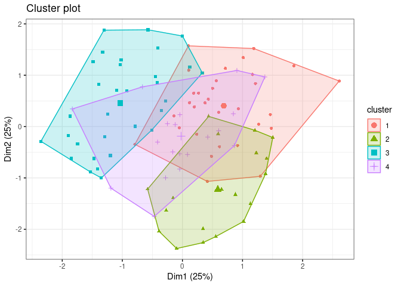

```r
res.4.4 <- analyse_clusters(recup_compos_X, data.clean, 4, 4)
res.4.4$plot.km
```

```r
res.4.4$res.table
```

|  | 1 | 2 | 3 | 4 | Overall |
| --- | --- | --- | --- | --- | --- |
|  | (N=31) | (N=19) | (N=31) | (N=19) | (N=100) |
| X09x3_FAB_CROISS_reg_rec |  |  |  |  |  |
| 0 | 19 (61.3%) | 16 (84.2%) | 14 (45.2%) | 6 (31.6%) | 55 (55.0%) |
| 1 | 12 (38.7%) | 3 (15.8%) | 17 (54.8%) | 13 (68.4%) | 45 (45.0%) |
| X22x1_LOC_INF_rec |  |  |  |  |  |
| 0 | 13 (41.9%) | 11 (57.9%) | 18 (58.1%) | 14 (73.7%) | 56 (56.0%) |
| 1 | 18 (58.1%) | 8 (42.1%) | 13 (41.9%) | 5 (26.3%) | 44 (44.0%) |
| X06x1_gene_majo_1_rec |  |  |  |  |  |
| 0 | 1 (3.2%) | 5 (26.3%) | 7 (22.6%) | 8 (42.1%) | 21 (21.0%) |
| 1 | 30 (96.8%) | 14 (73.7%) | 24 (77.4%) | 11 (57.9%) | 79 (79.0%) |
| X12x2_MAT_PC |  |  |  |  |  |
| 1 | 10 (32.3%) | 9 (47.4%) | 7 (22.6%) | 10 (52.6%) | 36 (36.0%) |
| 2 | 21 (67.7%) | 10 (52.6%) | 24 (77.4%) | 9 (47.4%) | 64 (64.0%) |
| T10_PS_EauDebi_3 |  |  |  |  |  |
| 0 | 9 (29.0%) | 7 (36.8%) | 16 (51.6%) | 10 (52.6%) | 42 (42.0%) |
| 1 | 20 (64.5%) | 4 (21.1%) | 9 (29.0%) | 6 (31.6%) | 39 (39.0%) |
| 2 | 2 (6.5%) | 8 (42.1%) | 6 (19.4%) | 3 (15.8%) | 19 (19.0%) |
| X12x2_MAT1FRLAV_1 |  |  |  |  |  |
| 0 | 16 (51.6%) | 3 (15.8%) | 3 (9.7%) | 5 (26.3%) | 27 (27.0%) |
| 1 | 12 (38.7%) | 6 (31.6%) | 9 (29.0%) | 10 (52.6%) | 37 (37.0%) |
| 2 | 3 (9.7%) | 10 (52.6%) | 19 (61.3%) | 4 (21.1%) | 36 (36.0%) |
| X07x1_AN_CONST4_mean_3 |  |  |  |  |  |
| 0 | 16 (51.6%) | 3 (15.8%) | 6 (19.4%) | 8 (42.1%) | 33 (33.0%) |
| 1 | 3 (9.7%) | 2 (10.5%) | 12 (38.7%) | 8 (42.1%) | 25 (25.0%) |
| 2 | 12 (38.7%) | 14 (73.7%) | 13 (41.9%) | 3 (15.8%) | 42 (42.0%) |
| T16_BS_TenueSpeciElev |  |  |  |  |  |
| 0 | 4 (12.9%) | 4 (21.1%) | 8 (25.8%) | 3 (15.8%) | 19 (19.0%) |
| 1 | 27 (87.1%) | 15 (78.9%) | 23 (74.2%) | 16 (84.2%) | 81 (81.0%) |
| X13x2_QUAI_t |  |  |  |  |  |
| 0 | 11 (35.5%) | 12 (63.2%) | 22 (71.0%) | 7 (36.8%) | 52 (52.0%) |
| 1 | 20 (64.5%) | 7 (36.8%) | 9 (29.0%) | 12 (63.2%) | 48 (48.0%) |
| ENG_TROU |  |  |  |  |  |
| 0 | 29 (93.5%) | 12 (63.2%) | 12 (38.7%) | 17 (89.5%) | 70 (70.0%) |
| 1 | 2 (6.5%) | 7 (36.8%) | 19 (61.3%) | 2 (10.5%) | 30 (30.0%) |
| X25x1_ElvAlterChoiPers |  |  |  |  |  |
| 0 | 19 (61.3%) | 11 (57.9%) | 13 (41.9%) | 4 (21.1%) | 47 (47.0%) |
| 1 | 12 (38.7%) | 8 (42.1%) | 18 (58.1%) | 15 (78.9%) | 53 (53.0%) |
| LR_LRF |  |  |  |  |  |
| 0 | 30 (96.8%) | 18 (94.7%) | 20 (64.5%) | 16 (84.2%) | 84 (84.0%) |
| 1 | 1 (3.2%) | 1 (5.3%) | 11 (35.5%) | 3 (15.8%) | 16 (16.0%) |
| T13_ENG_milieuDegrad.x |  |  |  |  |  |
| 0 | 17 (54.8%) | 13 (68.4%) | 11 (35.5%) | 10 (52.6%) | 51 (51.0%) |
| 1 | 14 (45.2%) | 6 (31.6%) | 20 (64.5%) | 9 (47.4%) | 49 (49.0%) |
| X18x2_ABBTX_PS |  |  |  |  |  |
| 0 | 20 (64.5%) | 18 (94.7%) | 0 (0%) | 18 (94.7%) | 56 (56.0%) |
| 1 | 11 (35.5%) | 1 (5.3%) | 31 (100%) | 1 (5.3%) | 44 (44.0%) |
| X19x2_ABB_E |  |  |  |  |  |
| 0 | 8 (25.8%) | 17 (89.5%) | 3 (9.7%) | 15 (78.9%) | 43 (43.0%) |
| 1 | 23 (74.2%) | 2 (10.5%) | 28 (90.3%) | 4 (21.1%) | 57 (57.0%) |
| A03_Pos10sVERS |  |  |  |  |  |
| 0 | 21 (67.7%) | 12 (63.2%) | 20 (64.5%) | 12 (63.2%) | 65 (65.0%) |
| 1 | 10 (32.3%) | 7 (36.8%) | 11 (35.5%) | 7 (36.8%) | 35 (35.0%) |
| A03_PosSeroMyAs |  |  |  |  |  |
| Non | 19 (61.3%) | 12 (63.2%) | 14 (45.2%) | 6 (31.6%) | 51 (51.0%) |
| Oui | 12 (38.7%) | 7 (36.8%) | 17 (54.8%) | 13 (68.4%) | 49 (49.0%) |
| T10_PS_AlimPoNourrLongpPo |  |  |  |  |  |
| Mean (SD) | 8.07 (5.13) | 6.27 (2.85) | 5.23 (1.73) | 7.15 (2.95) | 6.67 (3.64) |
| Median [Min, Max] | 6.67 [1.19, 25.9] | 6.67 [1.88, 14.8] | 5.00 [2.09, 8.26] | 6.92 [1.20, 12.8] | 6.67 [1.19, 25.9] |
| A03_TxPosSero22sTgReel |  |  |  |  |  |
| Mean (SD) | 6.30 (14.6) | 9.49 (22.0) | 9.07 (19.9) | 0.125 (0.189) | 6.59 (16.8) |
| Median [Min, Max] | 0 [0, 55.0] | 0 [0, 82.4] | 0.396 [0, 82.4] | 0 [0, 0.396] | 0 [0, 82.4] |
| A04_My10Mfloc |  |  |  |  |  |
| absence | 20 (64.5%) | 11 (57.9%) | 19 (61.3%) | 7 (36.8%) | 57 (57.0%) |
| modéré | 7 (22.6%) | 3 (15.8%) | 9 (29.0%) | 9 (47.4%) | 28 (28.0%) |
| élevé | 4 (12.9%) | 5 (26.3%) | 3 (9.7%) | 3 (15.8%) | 15 (15.0%) |
| A05_TxPos10sGRIPPEReel |  |  |  |  |  |
| Mean (SD) | 8.34 (23.6) | 22.5 (35.2) | 36.1 (41.8) | 43.6 (43.9) | 26.3 (38.3) |
| Median [Min, Max] | 0 [0, 100] | 0 [0, 100] | 10.6 [0, 100] | 42.2 [0, 100] | 0 [0, 100] |
| y |  |  |  |  |  |
| ENG_malade | 4 (12.9%) | 3 (15.8%) | 20 (64.5%) | 11 (57.9%) | 38 (38.0%) |
| PS_malade | 13 (41.9%) | 7 (36.8%) | 6 (19.4%) | 4 (21.1%) | 30 (30.0%) |
| Sain | 14 (45.2%) | 9 (47.4%) | 5 (16.1%) | 4 (21.1%) | 32 (32.0%) |

```r
res.4.4$res.catdes
```

```
## $`1`
##                            Cla/Mod   Mod/Cla Global      p.value    v.test
## ENG_TROU=0               41.428571 93.548387     70 0.0003178378  3.600310
## X12x2_MAT1FRLAV_1=0      59.259259 51.612903     27 0.0003934596  3.544432
## T10_PS_EauDebi_3=1       51.282051 64.516129     39 0.0006344334  3.416450
## X06x1_gene_majo_1_rec=1  37.974684 96.774194     79 0.0020198449  3.087299
## X07x1_AN_CONST4_mean_3=0 48.484848 51.612903     33 0.0104930467  2.559143
## LR_LRF=0                 35.714286 96.774194     84 0.0159003334  2.411195
## X19x2_ABB_E=1            40.350877 74.193548     57 0.0211571096  2.305169
## X13x2_QUAI_t=1           41.666667 64.516129     48 0.0297787786  2.173020
## X13x2_QUAI_t=0           21.153846 35.483871     52 0.0297787786 -2.173020
## T10_PS_EauDebi_3=2       10.526316  6.451613     19 0.0297294952 -2.173676
## X19x2_ABB_E=0            18.604651 25.806452     43 0.0211571096 -2.305169
## X07x1_AN_CONST4_mean_3=1 12.000000  9.677419     25 0.0161474101 -2.405567
## LR_LRF=1                  6.250000  3.225806     16 0.0159003334 -2.411195
## X06x1_gene_majo_1_rec=0   4.761905  3.225806     21 0.0020198449 -3.087299
## y=ENG_malade             10.526316 12.903226     38 0.0004094366 -3.533925
## ENG_TROU=1                6.666667  6.451613     30 0.0003178378 -3.600310
## X12x2_MAT1FRLAV_1=2       8.333333  9.677419     36 0.0001486347 -3.793339
##
## $`2`
##                              Cla/Mod   Mod/Cla Global      p.value    v.test
## X19x2_ABB_E=0              39.534884 89.473684     43 5.615347e-06  4.540378
## X18x2_ABBTX_PS=0           32.142857 94.736842     56 7.701090e-05  3.953517
## X07x1_AN_CONST4_mean_3=2   33.333333 73.684211     42 2.547187e-03  3.017679
## X09x3_FAB_CROISS_reg_rec=0 29.090909 84.210526     55 4.313095e-03  2.854306
## T10_PS_EauDebi_3=2         42.105263 42.105263     19 9.950347e-03  2.577550
## y=ENG_malade                7.894737 15.789474     38 2.640844e-02 -2.220152
## X09x3_FAB_CROISS_reg_rec=1  6.666667 15.789474     45 4.313095e-03 -2.854306
## X18x2_ABBTX_PS=1            2.272727  5.263158     44 7.701090e-05 -3.953517
## X19x2_ABB_E=1               3.508772 10.526316     57 5.615347e-06 -4.540378
##
## $`3`
##                            Cla/Mod    Mod/Cla Global      p.value    v.test
## X18x2_ABBTX_PS=1         70.454545 100.000000     44 7.827487e-16  8.056867
## X19x2_ABB_E=1            49.122807  90.322581     57 3.225226e-06  4.655929
## ENG_TROU=1               63.333333  61.290323     30 1.090623e-05  4.398379
## y=ENG_malade             52.631579  64.516129     38 3.659718e-04  3.563479
## X12x2_MAT1FRLAV_1=2      52.777778  61.290323     36 6.185064e-04  3.423366
## LR_LRF=1                 68.750000  35.483871     16 9.053595e-04  3.318396
```

[output cut: 13 more lines]

```
##                              Cla/Mod   Mod/Cla Global      p.value    v.test
## X18x2_ABBTX_PS=0           32.142857 94.736842     56 0.0000770109  3.953517
## X19x2_ABB_E=0              34.883721 78.947368     43 0.0005802463  3.440684
## X25x1_ElvAlterChoiPers=1   28.301887 78.947368     53 0.0126371218  2.493835
## X06x1_gene_majo_1_rec=0    38.095238 42.105263     21 0.0215447748  2.298299
## X09x3_FAB_CROISS_reg_rec=1 28.888889 68.421053     45 0.0268250779  2.214054
## ENG_TROU=0                 24.285714 89.473684     70 0.0373702455  2.081696
## A04_My10Mfloc=modéré       32.142857 47.368421     28 0.0495236584  1.964055
## ENG_TROU=1                  6.666667 10.526316     30 0.0373702455 -2.081696
## X09x3_FAB_CROISS_reg_rec=0 10.909091 31.578947     55 0.0268250779 -2.214054
## X06x1_gene_majo_1_rec=1    13.924051 57.894737     79 0.0215447748 -2.298299
## X25x1_ElvAlterChoiPers=0    8.510638 21.052632     47 0.0126371218 -2.493835
## X07x1_AN_CONST4_mean_3=2    7.142857 15.789474     42 0.0098065481 -2.582577
## X19x2_ABB_E=1               7.017544 21.052632     57 0.0005802463 -3.440684
## X18x2_ABBTX_PS=1            2.272727  5.263158     44 0.0000770109 -3.953517
```

___ PS_malade (blocs 1 et 2) ___

___ Remarque ___

### Hdbscan

```r
res.hdb.4 <- clasif.hdbscan(recup_compos_X, 4)
```

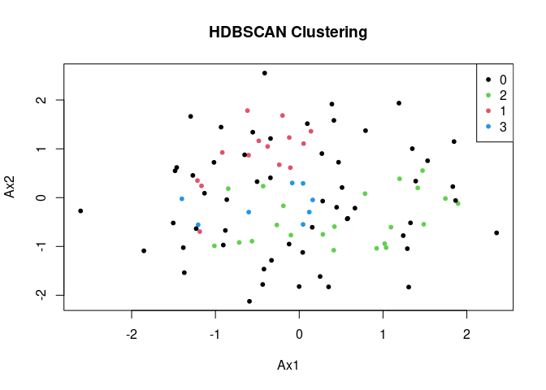

```r
res.hdb.4
```

```
## HDBSCAN clustering for 100 objects.
## Parameters: minPts = 5
## The clustering contains 3 cluster(s) and 56 noise points.
##
##  0  1  2  3
## 56 14 22  8
##
## Available fields: cluster, minPts, coredist, cluster_scores,
##                   membership_prob, outlier_scores, hc
```

56 élevages non pris classifiés.

### Modèle de mèlanges gaussien

Justification choix de modèle : * Contrairement à k-NN, qui se base uniquement sur la proximité des points dans l’espace, GMM peut mieux gérer les cas où les classes ne sont pas séparées de manière nette mais ont des distributions chevauchantes. * moins suceptible au fléau de a dimension que knn * On ne suppose rien : volume, orientation, variance ### 2 dimensions

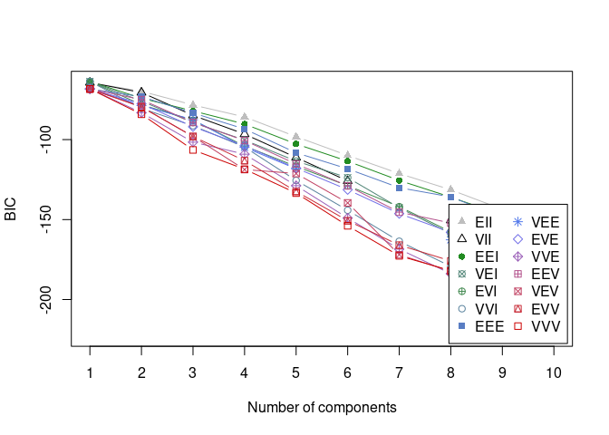

```r
par(mfrow = c(1, 1))

X.2 <- res.mbpls2$lX[, 1:2]
fit <- Mclust(X.2, G = 1:10)
plot(fit, "BIC")
```

### 4 dimensions

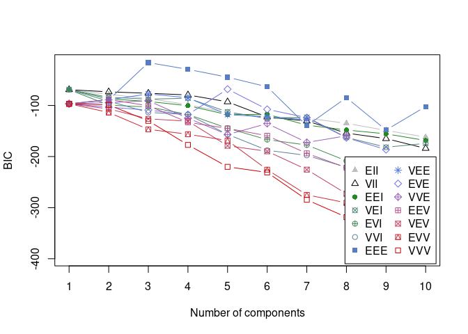

```r
X.4 <- res.mbpls2$lX[, 1:4]
models <- Mclust(X.4, G = 1:10)
plot(models, "BIC")
```

# EEE

```r
# Choix nombre clusters
gmm_model <- Mclust(X.4, G = 3, modelNames = "EEE")

clusters <- gmm_model$classification
summary(factor(clusters))
```

```
##  1  2  3
## 36 37 27
```

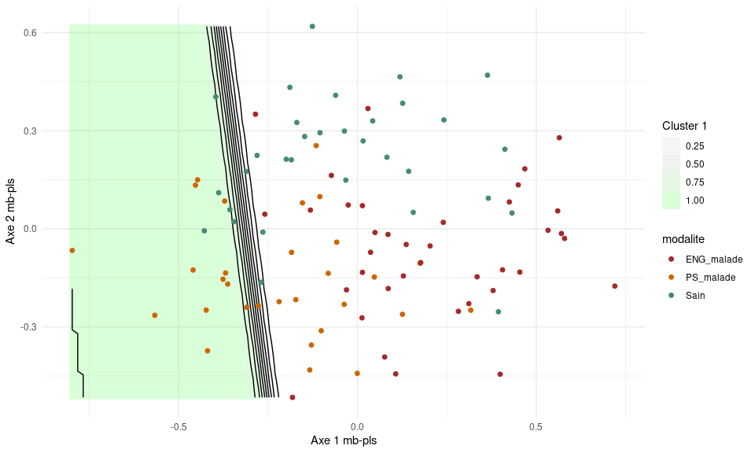

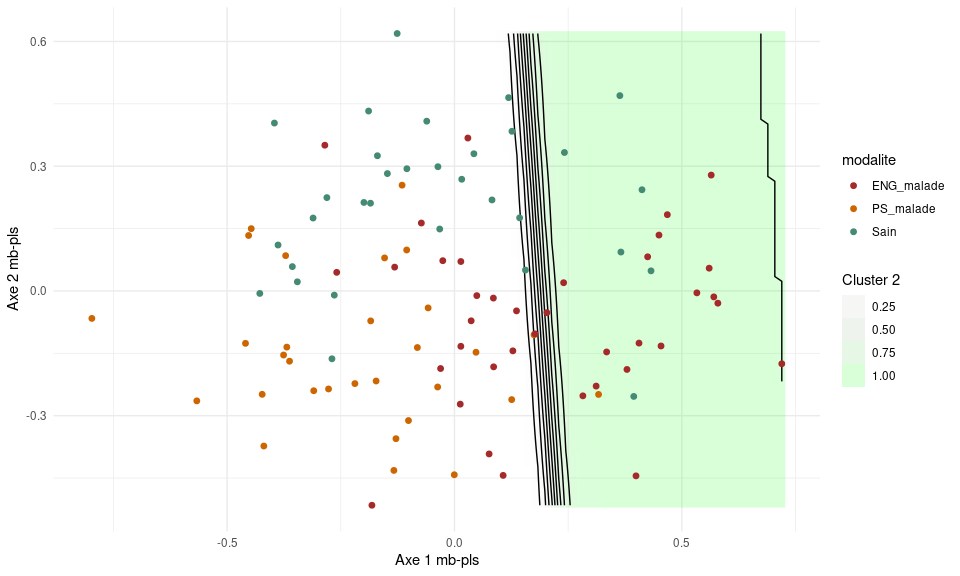

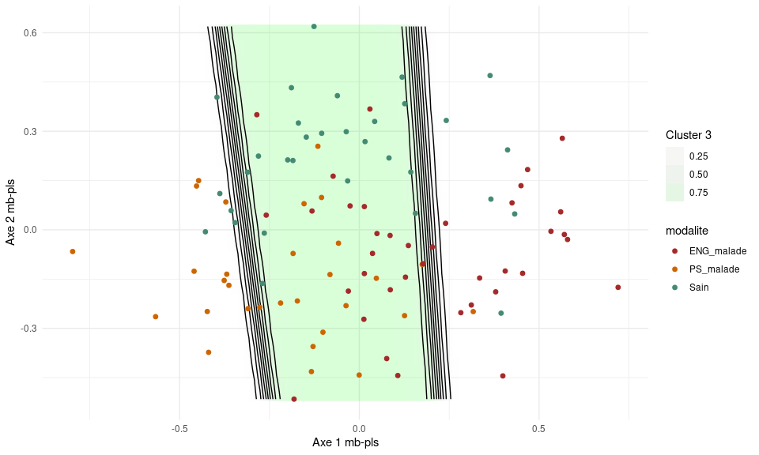

```r
# Création de la grille 2D avec noms originaux
original_names <- colnames(recup_compos_X)[1:2]

grid <- expand.grid(
  seq(min(X.4[,1]), max(X.4[,1]), length.out = 100),
  seq(min(X.4[,2]), max(X.4[,2]), length.out = 100),
  median(X.4[,3]),
  median(X.4[,4])
)
colnames(grid) <- original_names

# Prédiction
grid_probs <- predict(gmm_model, newdata = grid)$z

# Données pour les points
plot_func <- function(cluster) {

    grid$prob_cluster <- grid_probs[, cluster]

    # Data for points
    plot_data <- data.frame(
      X.4[, 1:2],
      modalite = factor(data.clean$y, levels = c("ENG_malade", "PS_malade", "Sain"))
    )
    colnames(plot_data)[1:2] <- original_names[1:2]

    # Create plot
    print(ggplot(grid, aes_string(x = original_names[1], y = original_names[2])) +
      geom_raster(aes(fill = prob_cluster), interpolate = TRUE) +
      geom_contour(aes(z = prob_cluster), color = "black", bins = 10) +
      scale_fill_gradient(low = rgb(0,0,0,0), high = rgb(0,1,0,0.15)) +
      geom_point(
        data = plot_data,
        aes_string(x = original_names[1], y = original_names[2], color = "modalite"),
        size = 1.75
      ) +
      scale_color_manual(
        values = c("ENG_malade" = "#A52A2A", "PS_malade" = "#CD6600", "Sain" = "#458B74")
      ) +
      labs(x = "Axe 1 mb-pls", y = "Axe 2 mb-pls") +
      theme_minimal() +
      guides(fill = guide_legend(title = paste("Cluster", cluster))))


}

for (cluster in 1:3) {
  plot_func(cluster)
}
```

### Test des hyp : Normalité

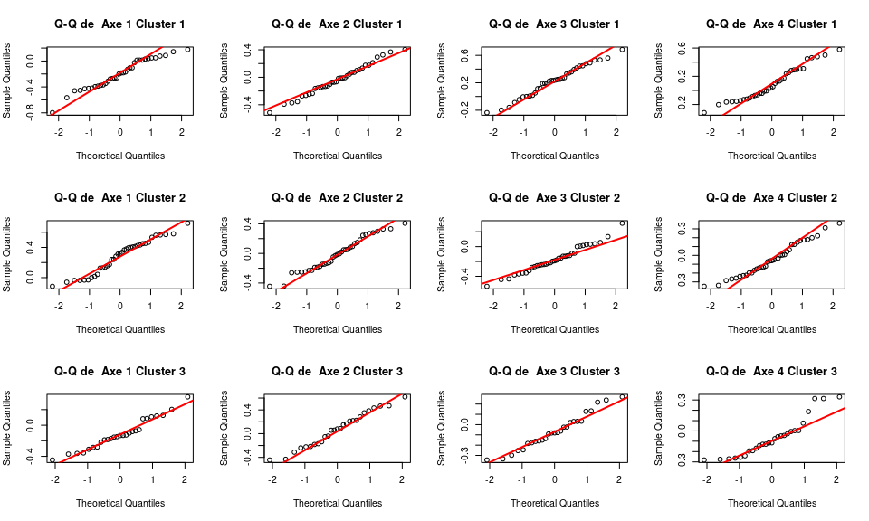

```r
plot_qq <- function(component, comp_name) {
  qqnorm(component, main = paste("Q-Q de ", comp_name))
  qqline(component, col = "red", lwd = 2)
}

norm_test  <- function(component, comp_name) {
  shapiro_test <- shapiro.test(component)
  print(paste(comp_name, "Shapiro-Wilk test p-value:", shapiro_test$p.value))
}

# Normalité des clusters
res.mb <- data.frame(cbind(X.4, factor(clusters)))
colnames(res.mb) <- c("Ax1", "Ax2", "Ax3", "Ax4", "clust")
par(mfrow = c(3, 4))

for (j in 1:3){
  for (i in 1:4) {
  plot_qq(res.mb[res.mb$clust==j,][, i], paste(paste(paste("Axe", i), "Cluster"), j))
  }
}
```

```r
for (j in 1:3){
  for (i in 1:4) {
  norm_test(res.mb[res.mb$clust==j,][, i], paste(paste(paste("Axe", i), "Cluster"), j))
  }
}
```

```
## [1] "Axe 1 Cluster 1 Shapiro-Wilk test p-value: 0.209007715968217"
## [1] "Axe 2 Cluster 1 Shapiro-Wilk test p-value: 0.973759021234535"
## [1] "Axe 3 Cluster 1 Shapiro-Wilk test p-value: 0.755259823815113"
## [1] "Axe 4 Cluster 1 Shapiro-Wilk test p-value: 0.134934551376698"
## [1] "Axe 1 Cluster 2 Shapiro-Wilk test p-value: 0.11468796415681"
## [1] "Axe 2 Cluster 2 Shapiro-Wilk test p-value: 0.3404190810229"
## [1] "Axe 3 Cluster 2 Shapiro-Wilk test p-value: 0.763239926911117"
## [1] "Axe 4 Cluster 2 Shapiro-Wilk test p-value: 0.398012296130356"
## [1] "Axe 1 Cluster 3 Shapiro-Wilk test p-value: 0.429846235125942"
## [1] "Axe 2 Cluster 3 Shapiro-Wilk test p-value: 0.730270676795563"
## [1] "Axe 3 Cluster 3 Shapiro-Wilk test p-value: 0.561098656259545"
## [1] "Axe 4 Cluster 3 Shapiro-Wilk test p-value: 0.00708411470074623"
```

```r
data_avec_clusters <- data.frame(data.clean, clusters = factor(clusters))

kable(table1(as.formula(~ . | clusters), data = data_avec_clusters))
```

|  | 1 | 2 | 3 | Overall |
| --- | --- | --- | --- | --- |
|  | (N=36) | (N=37) | (N=27) | (N=100) |
| X09x3_FAB_CROISS_reg_rec |  |  |  |  |
| 0 | 22 (61.1%) | 20 (54.1%) | 13 (48.1%) | 55 (55.0%) |
| 1 | 14 (38.9%) | 17 (45.9%) | 14 (51.9%) | 45 (45.0%) |
| X22x1_LOC_INF_rec |  |  |  |  |
| 0 | 23 (63.9%) | 19 (51.4%) | 14 (51.9%) | 56 (56.0%) |
| 1 | 13 (36.1%) | 18 (48.6%) | 13 (48.1%) | 44 (44.0%) |
| X06x1_gene_majo_1_rec |  |  |  |  |
| 0 | 10 (27.8%) | 9 (24.3%) | 2 (7.4%) | 21 (21.0%) |
| 1 | 26 (72.2%) | 28 (75.7%) | 25 (92.6%) | 79 (79.0%) |
| X12x2_MAT_PC |  |  |  |  |
| 1 | 17 (47.2%) | 12 (32.4%) | 7 (25.9%) | 36 (36.0%) |
| 2 | 19 (52.8%) | 25 (67.6%) | 20 (74.1%) | 64 (64.0%) |
| T10_PS_EauDebi_3 |  |  |  |  |
| 0 | 12 (33.3%) | 18 (48.6%) | 12 (44.4%) | 42 (42.0%) |
| 1 | 14 (38.9%) | 12 (32.4%) | 13 (48.1%) | 39 (39.0%) |
| 2 | 10 (27.8%) | 7 (18.9%) | 2 (7.4%) | 19 (19.0%) |
| X12x2_MAT1FRLAV_1 |  |  |  |  |
| 0 | 10 (27.8%) | 7 (18.9%) | 10 (37.0%) | 27 (27.0%) |
| 1 | 14 (38.9%) | 12 (32.4%) | 11 (40.7%) | 37 (37.0%) |
| 2 | 12 (33.3%) | 18 (48.6%) | 6 (22.2%) | 36 (36.0%) |
| X07x1_AN_CONST4_mean_3 |  |  |  |  |
| 0 | 13 (36.1%) | 12 (32.4%) | 8 (29.6%) | 33 (33.0%) |
| 1 | 8 (22.2%) | 11 (29.7%) | 6 (22.2%) | 25 (25.0%) |
| 2 | 15 (41.7%) | 14 (37.8%) | 13 (48.1%) | 42 (42.0%) |
| T16_BS_TenueSpeciElev |  |  |  |  |
| 0 | 7 (19.4%) | 9 (24.3%) | 3 (11.1%) | 19 (19.0%) |
| 1 | 29 (80.6%) | 28 (75.7%) | 24 (88.9%) | 81 (81.0%) |
| X13x2_QUAI_t |  |  |  |  |
| 0 | 18 (50.0%) | 22 (59.5%) | 12 (44.4%) | 52 (52.0%) |
| 1 | 18 (50.0%) | 15 (40.5%) | 15 (55.6%) | 48 (48.0%) |
| ENG_TROU |  |  |  |  |
| 0 | 29 (80.6%) | 20 (54.1%) | 21 (77.8%) | 70 (70.0%) |
| 1 | 7 (19.4%) | 17 (45.9%) | 6 (22.2%) | 30 (30.0%) |
| X25x1_ElvAlterChoiPers |  |  |  |  |
| 0 | 19 (52.8%) | 14 (37.8%) | 14 (51.9%) | 47 (47.0%) |
| 1 | 17 (47.2%) | 23 (62.2%) | 13 (48.1%) | 53 (53.0%) |
| LR_LRF |  |  |  |  |
| 0 | 33 (91.7%) | 27 (73.0%) | 24 (88.9%) | 84 (84.0%) |
| 1 | 3 (8.3%) | 10 (27.0%) | 3 (11.1%) | 16 (16.0%) |
| T13_ENG_milieuDegrad.x |  |  |  |  |
| 0 | 22 (61.1%) | 12 (32.4%) | 17 (63.0%) | 51 (51.0%) |
| 1 | 14 (38.9%) | 25 (67.6%) | 10 (37.0%) | 49 (49.0%) |
| X18x2_ABBTX_PS |  |  |  |  |
| 0 | 36 (100%) | 0 (0%) | 20 (74.1%) | 56 (56.0%) |
| 1 | 0 (0%) | 37 (100%) | 7 (25.9%) | 44 (44.0%) |
| X19x2_ABB_E |  |  |  |  |
| 0 | 36 (100%) | 0 (0%) | 7 (25.9%) | 43 (43.0%) |
| 1 | 0 (0%) | 37 (100%) | 20 (74.1%) | 57 (57.0%) |
| A03_Pos10sVERS |  |  |  |  |
| 0 | 21 (58.3%) | 26 (70.3%) | 18 (66.7%) | 65 (65.0%) |
| 1 | 15 (41.7%) | 11 (29.7%) | 9 (33.3%) | 35 (35.0%) |
| A03_PosSeroMyAs |  |  |  |  |
| Non | 18 (50.0%) | 20 (54.1%) | 13 (48.1%) | 51 (51.0%) |
| Oui | 18 (50.0%) | 17 (45.9%) | 14 (51.9%) | 49 (49.0%) |
| T10_PS_AlimPoNourrLongpPo |  |  |  |  |
| Mean (SD) | 7.26 (4.34) | 5.79 (2.04) | 7.09 (4.20) | 6.67 (3.64) |
| Median [Min, Max] | 6.67 [1.19, 25.9] | 6.25 [2.09, 12.5] | 6.40 [1.63, 23.0] | 6.67 [1.19, 25.9] |
| A03_TxPosSero22sTgReel |  |  |  |  |
| Mean (SD) | 3.91 (13.0) | 7.61 (18.5) | 8.78 (19.1) | 6.59 (16.8) |
| Median [Min, Max] | 0 [0, 55.0] | 0 [0, 82.4] | 0 [0, 82.4] | 0 [0, 82.4] |
| A04_My10Mfloc |  |  |  |  |
| absence | 18 (50.0%) | 20 (54.1%) | 19 (70.4%) | 57 (57.0%) |
| modéré | 13 (36.1%) | 12 (32.4%) | 3 (11.1%) | 28 (28.0%) |
| élevé | 5 (13.9%) | 5 (13.5%) | 5 (18.5%) | 15 (15.0%) |
| A05_TxPos10sGRIPPEReel |  |  |  |  |
| Mean (SD) | 27.6 (38.1) | 33.2 (41.5) | 15.2 (32.3) | 26.3 (38.3) |
| Median [Min, Max] | 0 [0, 100] | 0 [0, 100] | 0 [0, 100] | 0 [0, 100] |
| y |  |  |  |  |
| ENG_malade | 12 (33.3%) | 20 (54.1%) | 6 (22.2%) | 38 (38.0%) |
| PS_malade | 13 (36.1%) | 6 (16.2%) | 11 (40.7%) | 30 (30.0%) |
| Sain | 11 (30.6%) | 11 (29.7%) | 10 (37.0%) | 32 (32.0%) |

```r
catdes(data_avec_clusters, num.var = ncol(data_avec_clusters), proba =0.05)$category
```

```
## $`1`
##                   Cla/Mod Mod/Cla Global      p.value    v.test
## X19x2_ABB_E=0    83.72093     100     43 1.629781e-20  9.284166
## X18x2_ABBTX_PS=0 64.28571     100     56 3.973355e-13  7.256466
## X18x2_ABBTX_PS=1  0.00000       0     44 3.973355e-13 -7.256466
## X19x2_ABB_E=1     0.00000       0     57 1.629781e-20 -9.284166
##
## $`2`
##                           Cla/Mod   Mod/Cla Global      p.value    v.test
## X18x2_ABBTX_PS=1         84.09091 100.00000     44 1.120475e-20  9.323988
## X19x2_ABB_E=1            64.91228 100.00000     57 3.538769e-13  7.272125
## T13_ENG_milieuDegrad.x=1 51.02041  67.56757     49 5.011627e-03  2.806285
## ENG_TROU=1               56.66667  45.94595     30 9.782694e-03  2.583417
## y=ENG_malade             52.63158  54.05405     38 1.339037e-02  2.473215
## LR_LRF=1                 62.50000  27.02703     16 2.838452e-02  2.191931
## X12x2_MAT1FRLAV_1=2      50.00000  48.64865     36 4.916195e-02  1.967184
## LR_LRF=0                 32.14286  72.97297     84 2.838452e-02 -2.191931
## y=PS_malade              20.00000  16.21622     30 2.154829e-02 -2.298237
## ENG_TROU=0               28.57143  54.05405     70 9.782694e-03 -2.583417
## T13_ENG_milieuDegrad.x=0 23.52941  32.43243     51 5.011627e-03 -2.806285
## X19x2_ABB_E=0             0.00000   0.00000     43 3.538769e-13 -7.272125
## X18x2_ABBTX_PS=0          0.00000   0.00000     56 1.120475e-20 -9.323988
##
## $`3`
##                          Cla/Mod   Mod/Cla Global    p.value    v.test
## X18x2_ABBTX_PS=0        35.71429 74.074074     56 0.02855973  2.189511
## X19x2_ABB_E=1           35.08772 74.074074     57 0.03819469  2.072759
## X06x1_gene_majo_1_rec=1 31.64557 92.592593     79 0.03979413  2.055879
## X06x1_gene_majo_1_rec=0  9.52381  7.407407     21 0.03979413 -2.055879
## X19x2_ABB_E=0           16.27907 25.925926     43 0.03819469 -2.072759
## X18x2_ABBTX_PS=1        15.90909 25.925926     44 0.02855973 -2.189511
## A04_My10Mfloc=modéré    10.71429 11.111111     28 0.02045751 -2.317849
```

# EVE

```r
# Choix nombre clusters
gmm_model <- Mclust(X.4, G = 5, modelNames = "EVE")

clusters <- gmm_model$classification
summary(factor(clusters))
```

```
##  1  2  3  4  5
##  7 33 30 15 15
```

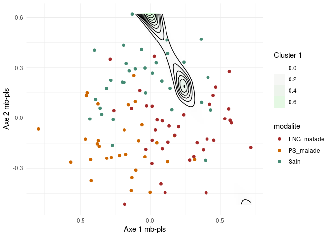

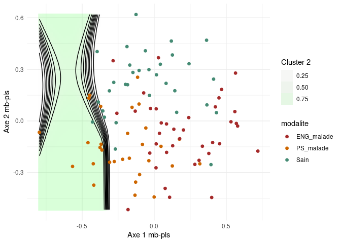

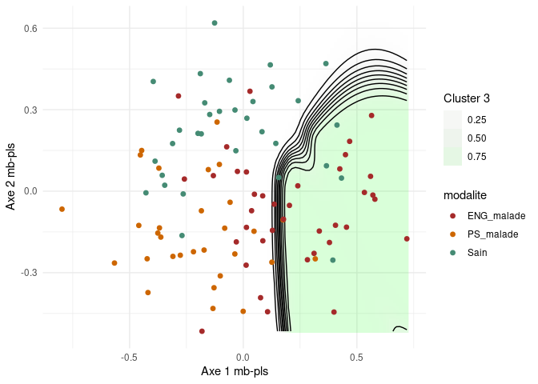

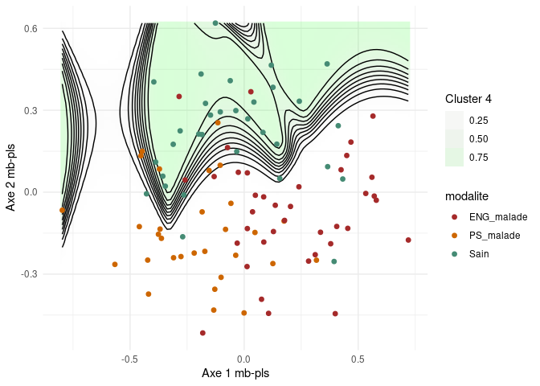

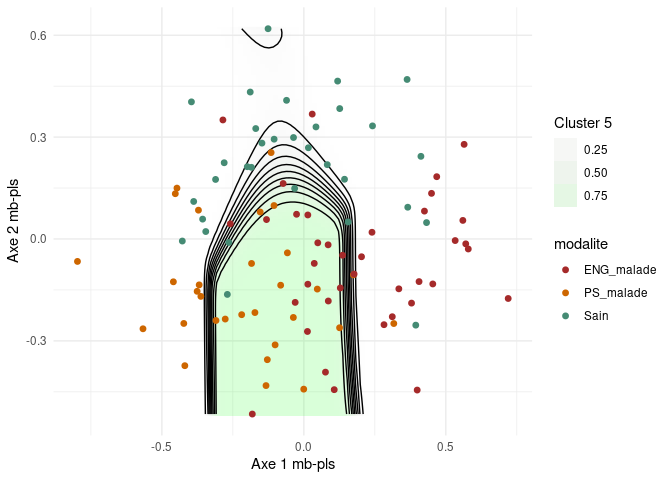

```r
# Prédiction
grid_probs <- predict(gmm_model, newdata = grid)$z
for (cluster in 1:5) {
  plot_func(cluster)
}
```

### Test des hyp : Normalité

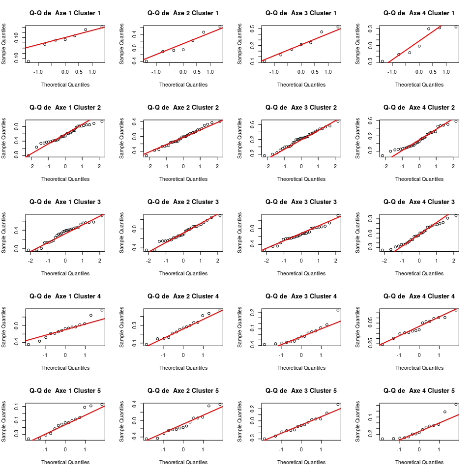

```r
res.mb <- data.frame(cbind(X.4, factor(clusters)))
colnames(res.mb) <- c("Ax1", "Ax2", "Ax3", "Ax4", "clust")

par(mfrow = c(5, 4))
for (j in 1:5){
  for (i in 1:4) {
  plot_qq(res.mb[res.mb$clust==j,][, i], paste(paste(paste("Axe", i), "Cluster"), j))
  }
}
```

```r
for (j in 1:5){
  for (i in 1:4) {
  norm_test(res.mb[res.mb$clust==j,][, i], paste(paste(paste("Axe", i), "Cluster"), j))
  }
}
```

```
## [1] "Axe 1 Cluster 1 Shapiro-Wilk test p-value: 0.422156168175403"
## [1] "Axe 2 Cluster 1 Shapiro-Wilk test p-value: 0.679373084583238"
## [1] "Axe 3 Cluster 1 Shapiro-Wilk test p-value: 0.915118762516793"
## [1] "Axe 4 Cluster 1 Shapiro-Wilk test p-value: 0.145309977671049"
## [1] "Axe 1 Cluster 2 Shapiro-Wilk test p-value: 0.318836702122943"
## [1] "Axe 2 Cluster 2 Shapiro-Wilk test p-value: 0.981049616277688"
## [1] "Axe 3 Cluster 2 Shapiro-Wilk test p-value: 0.911450248629339"
## [1] "Axe 4 Cluster 2 Shapiro-Wilk test p-value: 0.203030911277522"
## [1] "Axe 1 Cluster 3 Shapiro-Wilk test p-value: 0.329563164149068"
## [1] "Axe 2 Cluster 3 Shapiro-Wilk test p-value: 0.692885616479873"
## [1] "Axe 3 Cluster 3 Shapiro-Wilk test p-value: 0.764756699004856"
## [1] "Axe 4 Cluster 3 Shapiro-Wilk test p-value: 0.512893127603212"
## [1] "Axe 1 Cluster 4 Shapiro-Wilk test p-value: 0.791372483210961"
## [1] "Axe 2 Cluster 4 Shapiro-Wilk test p-value: 0.9034957326906"
## [1] "Axe 3 Cluster 4 Shapiro-Wilk test p-value: 0.0251431447263082"
## [1] "Axe 4 Cluster 4 Shapiro-Wilk test p-value: 0.816381461054593"
## [1] "Axe 1 Cluster 5 Shapiro-Wilk test p-value: 0.382357388975051"
## [1] "Axe 2 Cluster 5 Shapiro-Wilk test p-value: 0.300623636554842"
## [1] "Axe 3 Cluster 5 Shapiro-Wilk test p-value: 0.826182646676676"
## [1] "Axe 4 Cluster 5 Shapiro-Wilk test p-value: 0.014520017993384"
```

```r
data_with_clusters <- data.frame(data.clean, clusters = factor(clusters))

kable(table1(as.formula(~ . | clusters), data = data_with_clusters))
```

|  | 1 | 2 | 3 | 4 | 5 | Overall |
| --- | --- | --- | --- | --- | --- | --- |
|  | (N=7) | (N=33) | (N=30) | (N=15) | (N=15) | (N=100) |
| X09x3_FAB_CROISS_reg_rec |  |  |  |  |  |  |
| 0 | 4 (57.1%) | 21 (63.6%) | 14 (46.7%) | 13 (86.7%) | 3 (20.0%) | 55 (55.0%) |
| 1 | 3 (42.9%) | 12 (36.4%) | 16 (53.3%) | 2 (13.3%) | 12 (80.0%) | 45 (45.0%) |
| X22x1_LOC_INF_rec |  |  |  |  |  |  |
| 0 | 5 (71.4%) | 20 (60.6%) | 17 (56.7%) | 7 (46.7%) | 7 (46.7%) | 56 (56.0%) |
| 1 | 2 (28.6%) | 13 (39.4%) | 13 (43.3%) | 8 (53.3%) | 8 (53.3%) | 44 (44.0%) |
| X06x1_gene_majo_1_rec |  |  |  |  |  |  |
| 0 | 3 (42.9%) | 9 (27.3%) | 8 (26.7%) | 1 (6.7%) | 0 (0%) | 21 (21.0%) |
| 1 | 4 (57.1%) | 24 (72.7%) | 22 (73.3%) | 14 (93.3%) | 15 (100%) | 79 (79.0%) |
| X12x2_MAT_PC |  |  |  |  |  |  |
| 1 | 2 (28.6%) | 17 (51.5%) | 7 (23.3%) | 6 (40.0%) | 4 (26.7%) | 36 (36.0%) |
| 2 | 5 (71.4%) | 16 (48.5%) | 23 (76.7%) | 9 (60.0%) | 11 (73.3%) | 64 (64.0%) |
| T10_PS_EauDebi_3 |  |  |  |  |  |  |
| 0 | 4 (57.1%) | 9 (27.3%) | 16 (53.3%) | 6 (40.0%) | 7 (46.7%) | 42 (42.0%) |
| 1 | 2 (28.6%) | 14 (42.4%) | 7 (23.3%) | 9 (60.0%) | 7 (46.7%) | 39 (39.0%) |
| 2 | 1 (14.3%) | 10 (30.3%) | 7 (23.3%) | 0 (0%) | 1 (6.7%) | 19 (19.0%) |
| X12x2_MAT1FRLAV_1 |  |  |  |  |  |  |
| 0 | 1 (14.3%) | 9 (27.3%) | 2 (6.7%) | 8 (53.3%) | 7 (46.7%) | 27 (27.0%) |
| 1 | 3 (42.9%) | 14 (42.4%) | 10 (33.3%) | 7 (46.7%) | 3 (20.0%) | 37 (37.0%) |
| 2 | 3 (42.9%) | 10 (30.3%) | 18 (60.0%) | 0 (0%) | 5 (33.3%) | 36 (36.0%) |
| X07x1_AN_CONST4_mean_3 |  |  |  |  |  |  |
| 0 | 0 (0%) | 13 (39.4%) | 8 (26.7%) | 7 (46.7%) | 5 (33.3%) | 33 (33.0%) |
| 1 | 3 (42.9%) | 6 (18.2%) | 11 (36.7%) | 2 (13.3%) | 3 (20.0%) | 25 (25.0%) |
| 2 | 4 (57.1%) | 14 (42.4%) | 11 (36.7%) | 6 (40.0%) | 7 (46.7%) | 42 (42.0%) |
| T16_BS_TenueSpeciElev |  |  |  |  |  |  |
| 0 | 1 (14.3%) | 6 (18.2%) | 9 (30.0%) | 1 (6.7%) | 2 (13.3%) | 19 (19.0%) |
| 1 | 6 (85.7%) | 27 (81.8%) | 21 (70.0%) | 14 (93.3%) | 13 (86.7%) | 81 (81.0%) |
| X13x2_QUAI_t |  |  |  |  |  |  |
| 0 | 1 (14.3%) | 17 (51.5%) | 20 (66.7%) | 7 (46.7%) | 7 (46.7%) | 52 (52.0%) |
| 1 | 6 (85.7%) | 16 (48.5%) | 10 (33.3%) | 8 (53.3%) | 8 (53.3%) | 48 (48.0%) |
| ENG_TROU |  |  |  |  |  |  |
| 0 | 4 (57.1%) | 27 (81.8%) | 13 (43.3%) | 13 (86.7%) | 13 (86.7%) | 70 (70.0%) |
| 1 | 3 (42.9%) | 6 (18.2%) | 17 (56.7%) | 2 (13.3%) | 2 (13.3%) | 30 (30.0%) |
| X25x1_ElvAlterChoiPers |  |  |  |  |  |  |
| 0 | 2 (28.6%) | 17 (51.5%) | 13 (43.3%) | 7 (46.7%) | 8 (53.3%) | 47 (47.0%) |
| 1 | 5 (71.4%) | 16 (48.5%) | 17 (56.7%) | 8 (53.3%) | 7 (46.7%) | 53 (53.0%) |
| LR_LRF |  |  |  |  |  |  |
| 0 | 5 (71.4%) | 32 (97.0%) | 20 (66.7%) | 13 (86.7%) | 14 (93.3%) | 84 (84.0%) |
| 1 | 2 (28.6%) | 1 (3.0%) | 10 (33.3%) | 2 (13.3%) | 1 (6.7%) | 16 (16.0%) |
| T13_ENG_milieuDegrad.x |  |  |  |  |  |  |
| 0 | 4 (57.1%) | 21 (63.6%) | 10 (33.3%) | 7 (46.7%) | 9 (60.0%) | 51 (51.0%) |
| 1 | 3 (42.9%) | 12 (36.4%) | 20 (66.7%) | 8 (53.3%) | 6 (40.0%) | 49 (49.0%) |
| X18x2_ABBTX_PS |  |  |  |  |  |  |
| 0 | 7 (100%) | 33 (100%) | 0 (0%) | 8 (53.3%) | 8 (53.3%) | 56 (56.0%) |
| 1 | 0 (0%) | 0 (0%) | 30 (100%) | 7 (46.7%) | 7 (46.7%) | 44 (44.0%) |
| X19x2_ABB_E |  |  |  |  |  |  |
| 0 | 3 (42.9%) | 33 (100%) | 0 (0%) | 0 (0%) | 7 (46.7%) | 43 (43.0%) |
| 1 | 4 (57.1%) | 0 (0%) | 30 (100%) | 15 (100%) | 8 (53.3%) | 57 (57.0%) |
| A03_Pos10sVERS |  |  |  |  |  |  |
| 0 | 5 (71.4%) | 19 (57.6%) | 21 (70.0%) | 12 (80.0%) | 8 (53.3%) | 65 (65.0%) |
| 1 | 2 (28.6%) | 14 (42.4%) | 9 (30.0%) | 3 (20.0%) | 7 (46.7%) | 35 (35.0%) |
| A03_PosSeroMyAs |  |  |  |  |  |  |
| Non | 4 (57.1%) | 16 (48.5%) | 14 (46.7%) | 11 (73.3%) | 6 (40.0%) | 51 (51.0%) |
| Oui | 3 (42.9%) | 17 (51.5%) | 16 (53.3%) | 4 (26.7%) | 9 (60.0%) | 49 (49.0%) |
| T10_PS_AlimPoNourrLongpPo |  |  |  |  |  |  |
| Mean (SD) | 7.49 (7.15) | 7.45 (4.44) | 5.46 (1.83) | 7.27 (2.37) | 6.41 (2.98) | 6.67 (3.64) |
| Median [Min, Max] | 6.38 [1.88, 23.0] | 6.67 [1.19, 25.9] | 5.91 [2.09, 8.75] | 6.67 [5.00, 13.3] | 6.16 [1.63, 11.5] | 6.67 [1.19, 25.9] |
| A03_TxPosSero22sTgReel |  |  |  |  |  |  |
| Mean (SD) | 4.13 (6.79) | 4.26 (13.5) | 8.45 (19.9) | 7.45 (15.5) | 8.30 (21.9) | 6.59 (16.8) |
| Median [Min, Max] | 0.396 [0, 14.1] | 0 [0, 55.0] | 0.198 [0, 82.4] | 0 [0, 55.0] | 0 [0, 82.4] | 0 [0, 82.4] |
| A04_My10Mfloc |  |  |  |  |  |  |
| absence | 3 (42.9%) | 17 (51.5%) | 16 (53.3%) | 9 (60.0%) | 12 (80.0%) | 57 (57.0%) |
| modéré | 3 (42.9%) | 11 (33.3%) | 11 (36.7%) | 1 (6.7%) | 2 (13.3%) | 28 (28.0%) |
| élevé | 1 (14.3%) | 5 (15.2%) | 3 (10.0%) | 5 (33.3%) | 1 (6.7%) | 15 (15.0%) |
| A05_TxPos10sGRIPPEReel |  |  |  |  |  |  |
| Mean (SD) | 24.1 (35.9) | 28.8 (39.1) | 37.3 (41.9) | 10.9 (28.2) | 15.4 (34.8) | 26.3 (38.3) |
| Median [Min, Max] | 0 [0, 95.0] | 0 [0, 100] | 21.1 [0, 100] | 0 [0, 100] | 0 [0, 100] | 0 [0, 100] |
| y |  |  |  |  |  |  |
| ENG_malade | 4 (57.1%) | 9 (27.3%) | 20 (66.7%) | 1 (6.7%) | 4 (26.7%) | 38 (38.0%) |
| PS_malade | 0 (0%) | 13 (39.4%) | 5 (16.7%) | 3 (20.0%) | 9 (60.0%) | 30 (30.0%) |
| Sain | 3 (42.9%) | 11 (33.3%) | 5 (16.7%) | 11 (73.3%) | 2 (13.3%) | 32 (32.0%) |

```r
catdes(data_with_clusters, num.var = ncol(data_with_clusters), proba =0.05)$category
```

```
## $`1`
##                    Cla/Mod   Mod/Cla Global    p.value    v.test
## X18x2_ABBTX_PS=0 12.500000 100.00000     56 0.01448799  2.444931
## X13x2_QUAI_t=1   12.500000  85.71429     48 0.04906286  1.968045
## X13x2_QUAI_t=0    1.923077  14.28571     52 0.04906286 -1.968045
## X18x2_ABBTX_PS=1  0.000000   0.00000     44 0.01448799 -2.444931
##
## $`2`
##                     Cla/Mod    Mod/Cla Global      p.value    v.test
## X19x2_ABB_E=0      76.74419 100.000000     43 6.506223e-18  8.623282
## X18x2_ABBTX_PS=0   58.92857 100.000000     56 1.074780e-11  6.796115
## LR_LRF=0           38.09524  96.969697     84 1.014841e-02  2.570731
## X12x2_MAT_PC=1     47.22222  51.515152     36 2.766714e-02  2.201974
## T10_PS_EauDebi_3=0 21.42857  27.272727     42 3.857899e-02 -2.068650
## X12x2_MAT_PC=2     25.00000  48.484848     64 2.766714e-02 -2.201974
## LR_LRF=1            6.25000   3.030303     16 1.014841e-02 -2.570731
## X18x2_ABBTX_PS=1    0.00000   0.000000     44 1.074780e-11 -6.796115
## X19x2_ABB_E=1       0.00000   0.000000     57 6.506223e-18 -8.623282
##
## $`3`
##                            Cla/Mod    Mod/Cla Global      p.value    v.test
## X18x2_ABBTX_PS=1         68.181818 100.000000     44 3.913744e-15  7.857660
## X19x2_ABB_E=1            52.631579 100.000000     57 4.777076e-10  6.226258
## y=ENG_malade             52.631579  66.666667     38 1.683517e-04  3.762309
## ENG_TROU=1               56.666667  56.666667     30 2.651171e-04  3.647197
## X12x2_MAT1FRLAV_1=2      50.000000  60.000000     36 1.537095e-03  3.167587
## LR_LRF=1                 62.500000  33.333333     16 4.037668e-03  2.875204
## T13_ENG_milieuDegrad.x=1 40.816327  66.666667     49 2.309433e-02  2.271871
## T10_PS_EauDebi_3=1       17.948718  23.333333     39 3.710159e-02 -2.084644
## y=Sain                   15.625000  16.666667     32 3.152834e-02 -2.150340
## T13_ENG_milieuDegrad.x=0 19.607843  33.333333     51 2.309433e-02 -2.271871
## LR_LRF=0                 23.809524  66.666667     84 4.037668e-03 -2.875204
## X12x2_MAT1FRLAV_1=0       7.407407   6.666667     27 1.833298e-03 -3.115988
## ENG_TROU=0               18.571429  43.333333     70 2.651171e-04 -3.647197
## X19x2_ABB_E=0             0.000000   0.000000     43 4.777076e-10 -6.226258
## X18x2_ABBTX_PS=0          0.000000   0.000000     56 3.913744e-15 -7.857660
##
## $`4`
##                              Cla/Mod    Mod/Cla Global      p.value    v.test
## X19x2_ABB_E=1              26.315789 100.000000     57 8.706921e-05  3.924060
## y=Sain                     34.375000  73.333333     32 5.106021e-04  3.475132
## X09x3_FAB_CROISS_reg_rec=0 23.636364  86.666667     55 7.311523e-03  2.682312
## X12x2_MAT1FRLAV_1=0        29.629630  53.333333     27 2.169841e-02  2.295606
## A04_My10Mfloc=modéré        3.571429   6.666667     28 4.214910e-02 -2.032045
## T10_PS_EauDebi_3=2          0.000000   0.000000     19 3.214680e-02 -2.142580
## X09x3_FAB_CROISS_reg_rec=1  4.444444  13.333333     45 7.311523e-03 -2.682312
## y=ENG_malade                2.631579   6.666667     38 5.096371e-03 -2.800878
## X12x2_MAT1FRLAV_1=2         0.000000   0.000000     36 6.296675e-04 -3.418502
## X19x2_ABB_E=0               0.000000   0.000000     43 8.706921e-05 -3.924060
##
## $`5`
##                              Cla/Mod Mod/Cla Global     p.value    v.test
## X09x3_FAB_CROISS_reg_rec=1 26.666667      80     45 0.003909368  2.885384
## y=PS_malade                30.000000      60     30 0.010710611  2.552001
## X06x1_gene_majo_1_rec=1    18.987342     100     79 0.021282375  2.302937
## X06x1_gene_majo_1_rec=0     0.000000       0     21 0.021282375 -2.302937
## X09x3_FAB_CROISS_reg_rec=0  5.454545      20     55 0.003909368 -2.885384
```

# Analyse Clusters

Les modalités retenues pour caractériser les différents clusters sont celles dont la p-value est inférieure à 0,05, ce qui rend compte d’une corrélation avec le cluster.

Le cluster 1 suggère que si des antibiotiques sont disponibles en engraissement contre la toux, alors ils ne le sont pas en post-sevrage, et inversement. Cela semble cohérent, car une prise d’antibiotiques est souvent suffisante compte tenu de l’espérance de vie des cochons en élevage.

Le cluster 2 ne présente pas d’information utile dans le cadre de notre projet.

Le cluster 3 permet de caractériser les porcs malades en engraissement. Ces porcs ont généralement reçu des antibiotiques contre la toux, que ce soit en post-sevrage ou en engraissement. Ceci est cohérent si l’on considère que l’éleveur les administre après avoir constaté la maladie. Il est d’ailleurs possible qu’un cochon ait développé la maladie et reçu les antibiotiques en post-sevrage, puis que la maladie ait également été constatée en engraissement, le temps que les antibiotiques fassent effet. On peut également constater, dans les élevages hébergeant ces porcs, la présence de trous dans la cloison, ou encore l’absence de lavage de matériel, avec un milieu dégradé (sol sale et/ou humide). Ce manquement sanitaire semble être un facteur du développement des maladies respiratoires chez les porcs. (À noter que les porcs semblent être davantage malades dans les élevages labellisés.)

Quant au cluster 4, il permet de caractériser les cochons sains. Ces derniers ont également pu recevoir des antibiotiques en engraissement, ce qui semble s’interpréter dorénavant comme des porcs ayant vaincu la maladie, ou alors comme une administration préventive d’antibiotiques. Une donnée plus intéressante concerne l’alimentation des porcs sains, puisqu’ils sont nourris avec des produits locaux (issus de la ferme). Notons également que, pour ces porcs, le lavage du matériel est effectué une fois par semaine.

Finalement, le cluster 5 nous donne des renseignements sur les individus malades en post-sevrage. Il met en évidence des prédispositions dans le développement des maladies respiratoires chez le porc portant la génétique Large White*Landrace.